# Homework 2

Matt Lenko

January 11, 2015

### Exercise 7

| Observation # | Euclidean Distance |
| --- | --- |
| 1 | 3.000000 |
| 2 | 2.000000 |
| 3 | 3.162278 |
| 4 | 2.236068 |
| 5 | 1.414214 |
| 6 | 1.732051 |

2. Our prediction with *K* = 1 is Green because the 5 observation *X = (-1,0,1)* is the closest observation and is Green.
3. Our prediction with *K* = 3 is Red because the 2nd, 5th, and 6th observations are the closest observations. The probabilty of the test point being Red is 2/3 while the probability of it being Green is only 1/3. Thus we choose the higher probability *(2/3)* and predict Red.
4. We would expect a small *K* value to make the best prediction.

### Exercise 9

1. Quantitative variable(s) are mpg, displacement, weight, horsepower, and acceleration. Qualitative variable(s) are cylinders, year, origin, and name.
2. Range of each quantitative predictor:

| Level | Range |
| --- | --- |
| mpg | 9, 46.6 |
| displacement | 68, 455 |
| horsepower | 46, 230 |
| weight | 1613, 5140 |
| acceleration | 8, 24.8 |

3. Mean and Standard Deviation of each quantitative predictor:

| Level | Mean | Standard Deviation |
| --- | --- | --- |
| mpg | 23.4459 | 7.805 |
| displacement | 194.412 | 104.644 |
| horsepower | 104.4694 | 38.4912 |
| weight | 2977.5842 | 849.4026 |
| acceleration | 15.5413 | 2.7589 |

```r
SA = rbind(Auto[ c(1:9) , ], Auto[ c(85:392) , ])
```

| Level | Range | Mean | Standard Deviation |
| --- | --- | --- | --- |
| mpg | 11, 46.6 | 24.3685 | 7.8809 |
| displacement | 68, 455 | 187.7539 | 99.9395 |
| horsepower | 46, 230 | 100.9558 | 35.8956 |
| weight | 1649, 4997 | 2939.6435 | 812.6496 |
| acceleration | 8.5, 24.8 | 15.7183 | 2.6938 |

#### Figure 1

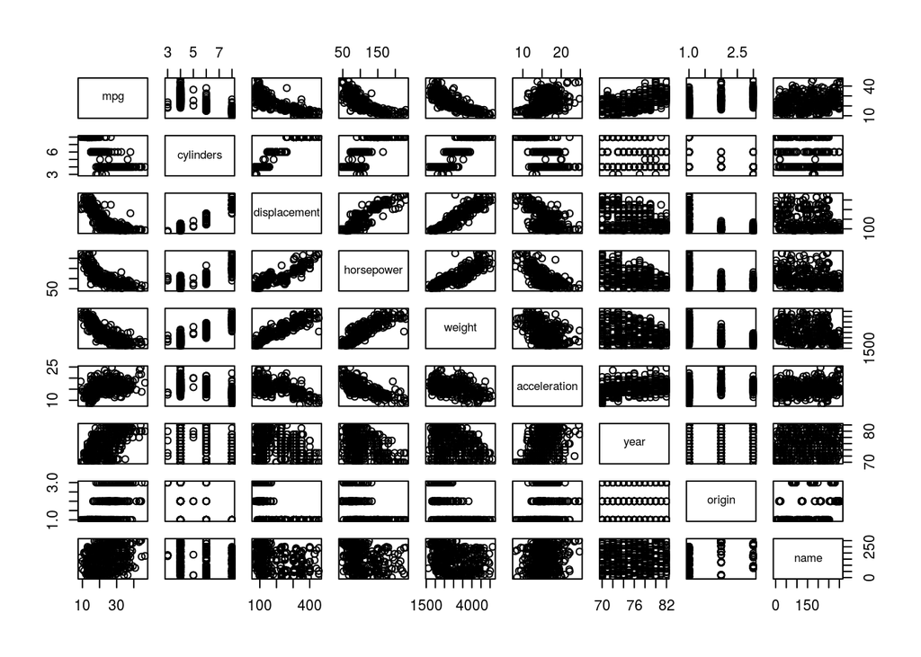

*Figure 1* shows pairs of scatter plots for all of the predictors against each other. This is the preliminary plot to help quickly identify any predictors at first glance.

#### Figure 2

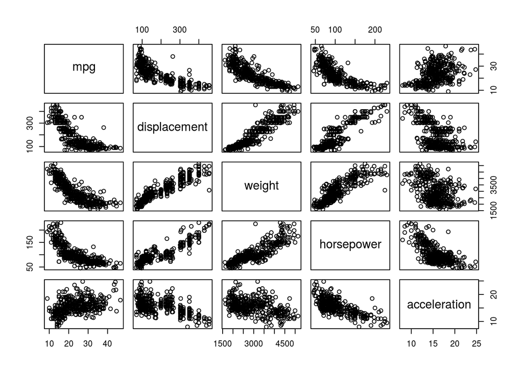

*Figure 2* shows scatter plots of the quantitative predictors against each other. This figure shows how there are many relationships between the quantitive variables. For instance due to the clustering in multiple of the scatter plots we can see that there are relationships between mpg and displacement of the engine. This data says that engines that are larger in volume, the amount they displace, result in lower fuel efficiencies. Another relationship that we can see is that weight and displacement most nearly have a linear relationship. The data suggests that as the engine displacement is increased the vehicle weight will inheritently increase as well. Yet another trend visible in *Figure 2* is that more horsepower typical results in a greater engine displacement. These are just a few of the trends and relationships in *Figure 2*.

#### Figure 3

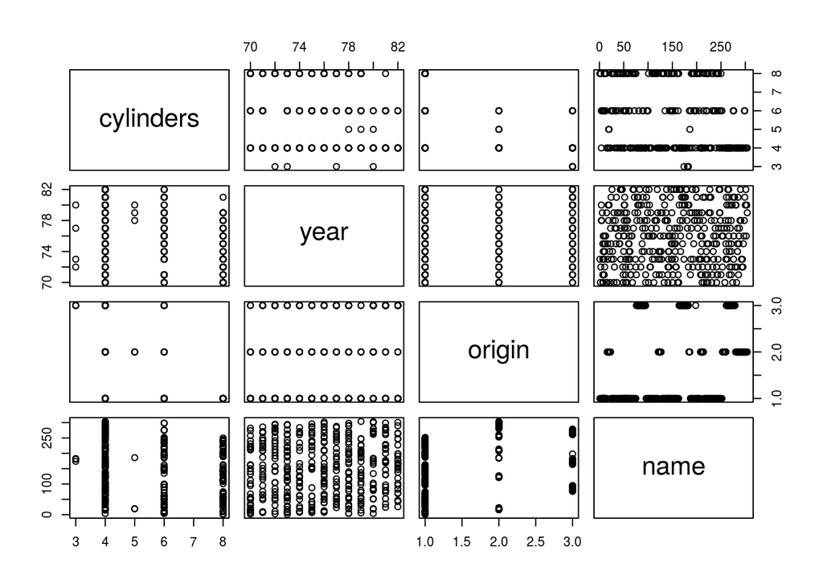

*Figure 3* shows scatter plots of the qualitative predictors against each other. The scatter plots do not make any trends between the qualitative easily recognizable if they are present.

#### Figure 4

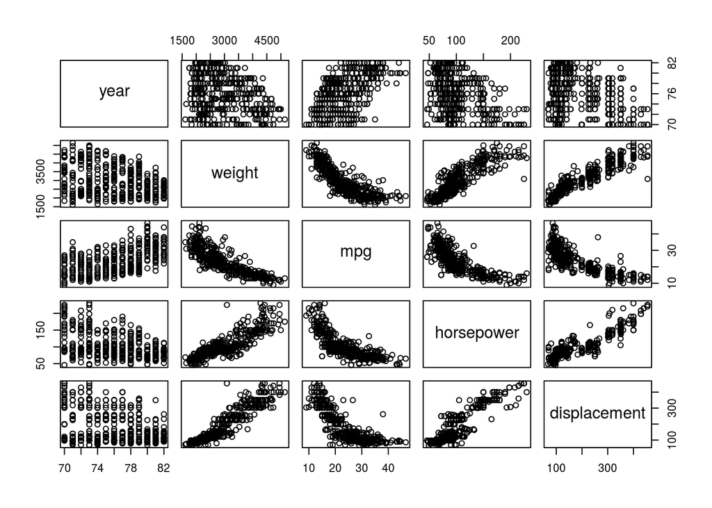

*Figure 4* shows the relationships between years and weight, mpg, horsepower, and dipslacement in the leftmost or upppermost scatterplots. We see a trend in lighter cars in the most recent years. We see an upward directed relationship between year and mpg. We see a downward trend in both horsepower and engine displacement as time moves forward.

#### Figure 5

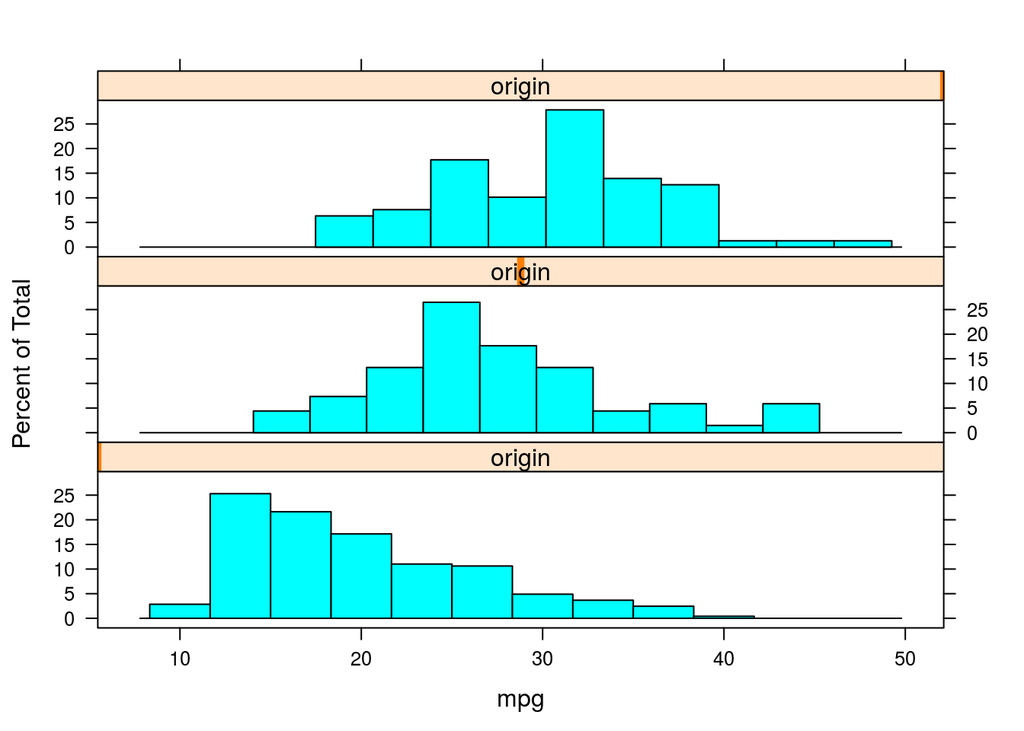

*Figure 5* shows the relationship between the origin of the car and the gas efficiency of the car. We see that American cars, bottom histogram, are generally the least fuel efficient vehicles with Japenese made cars, top histogram, having the greatest tendicy to get better mpg.

[figure not shown]

#### Figure 7

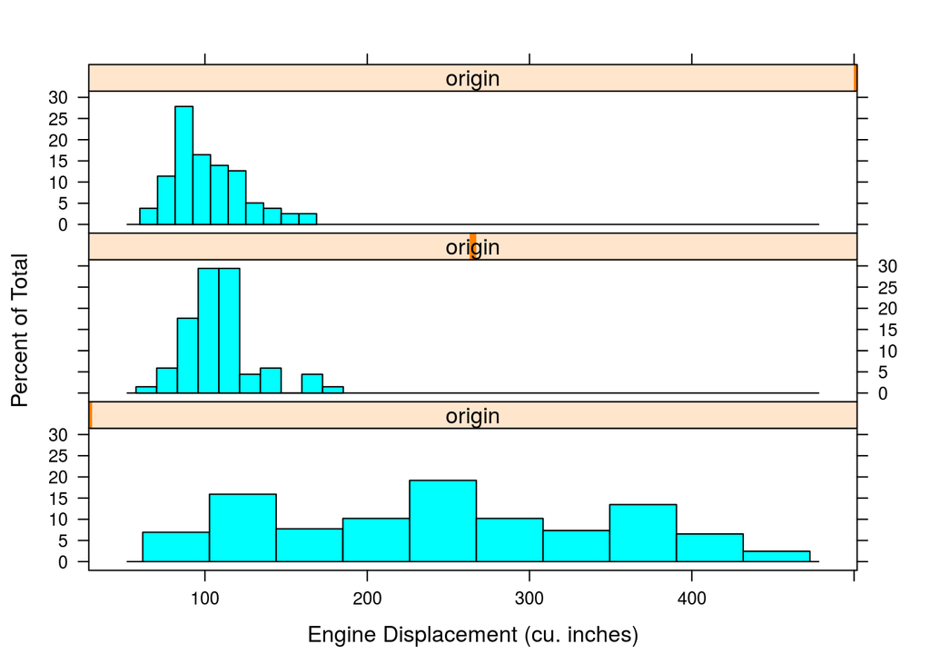

#### Figure 8

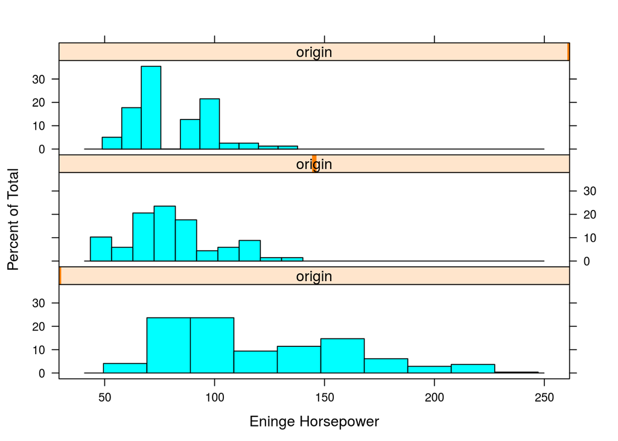

#### Figure 9

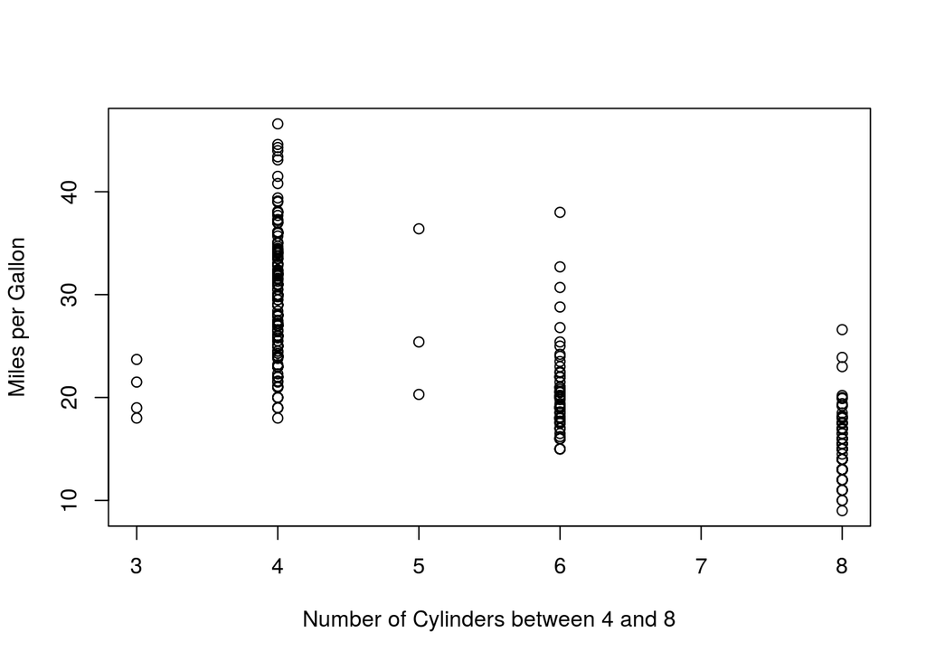

Figure 9 shows the relationship between the qualitative predictor Number of Cylinders and the quantitative miles per gallon.

6. My plots do suggest that some of the variables would be useful in predicting mpg. Cylinders, displacement, weight, year, and origin are variables that could be used to predict mpg. These are good choices of variables to use to predict mpg because from the plots without even applying trend line fits distinguishable trends/relationships are visible. They clearly play a factor into mpg and could be used to predict mpg based on values given.

### Exercise 10

1. The `Boston` data set has 506 rows and 14 columns. The rows and columns represent Housing Values in Suburbs of Boston. The rows are the responses while the columns hold different responses to questions.

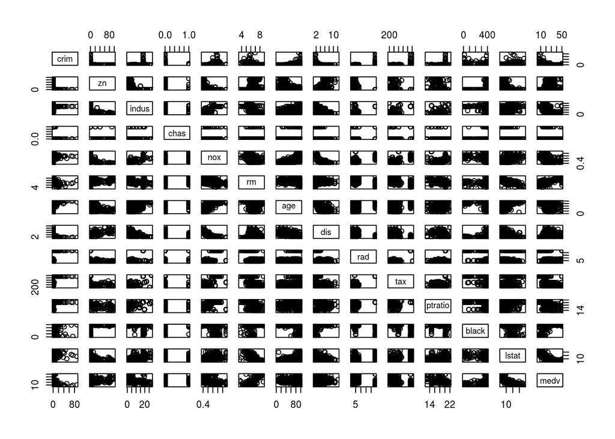

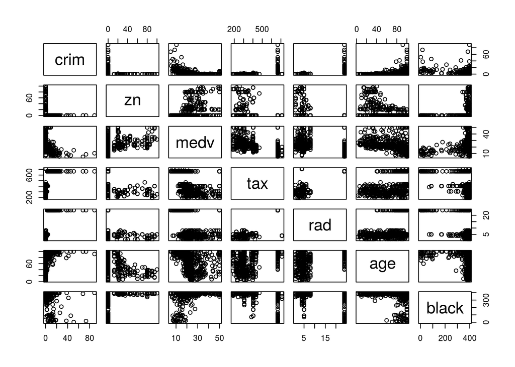

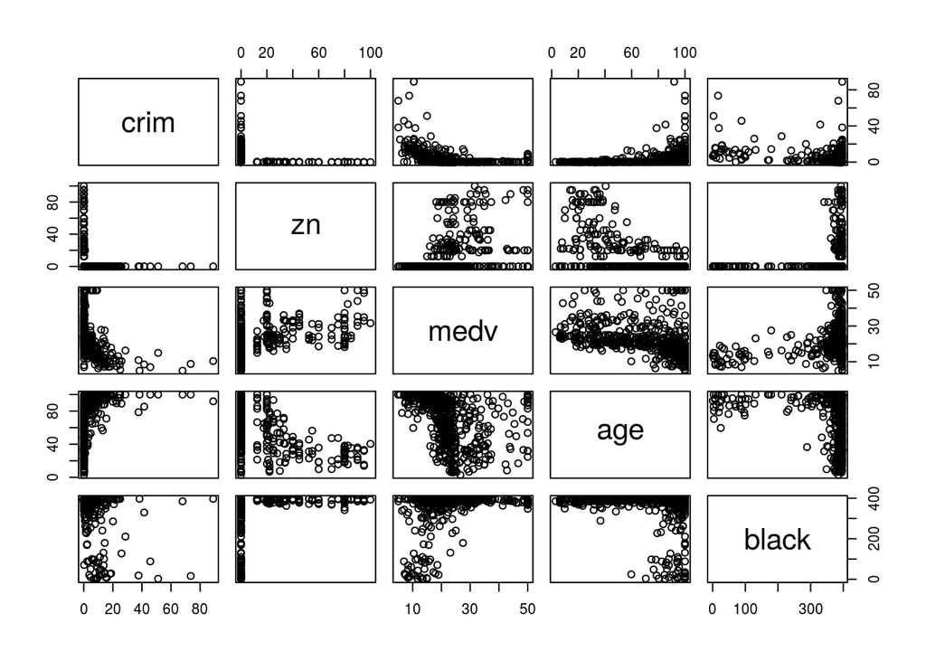

The data is unique and hard to understand, there do appear to be some relationships between a few predictors.

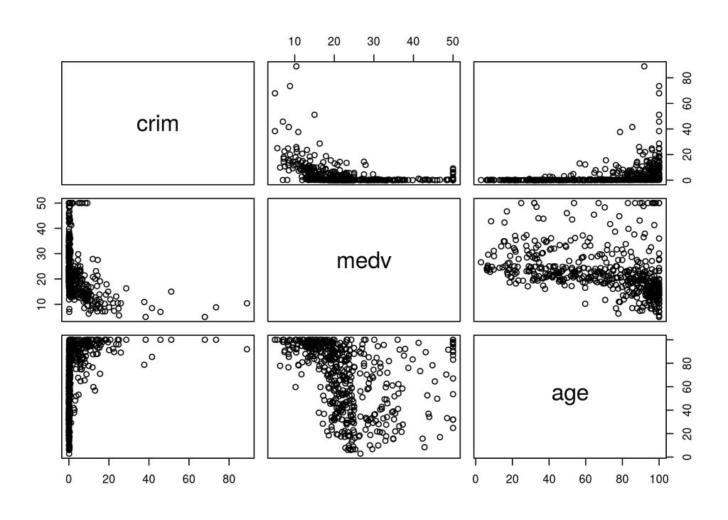

It seems to be the case that medv and age are associated with per capita crime rate.

#### Per Capita Crime Rate

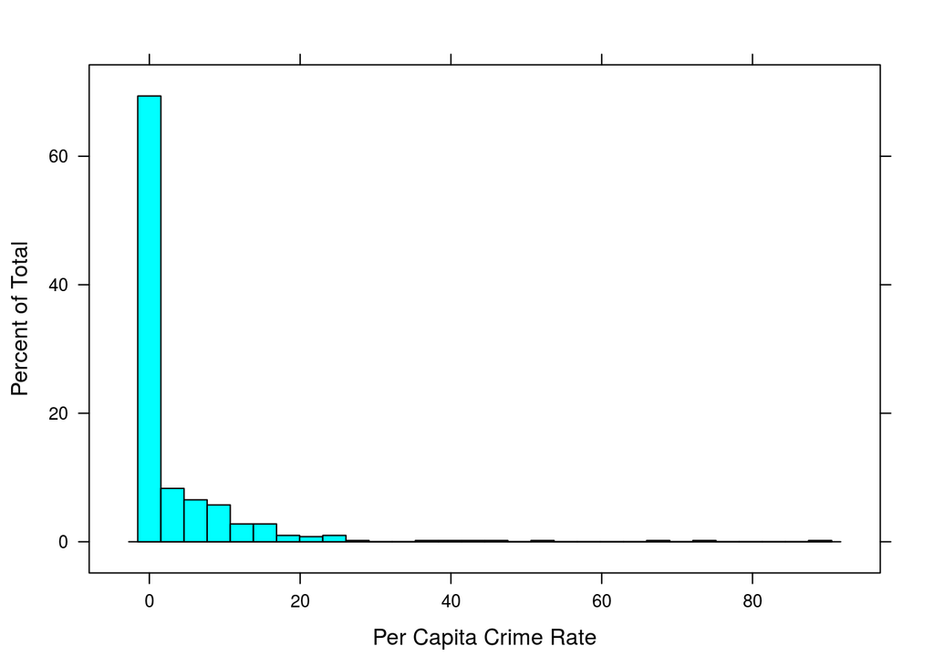

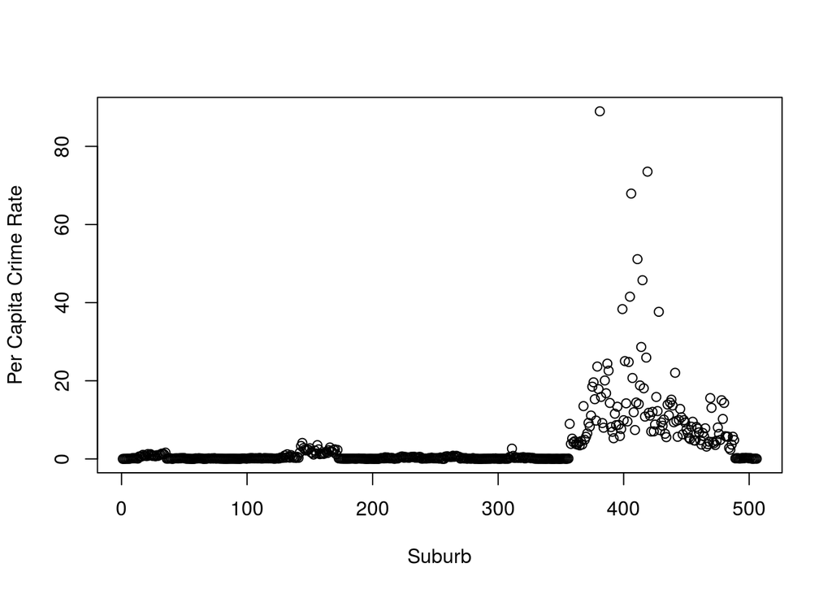

#### Tax Rate

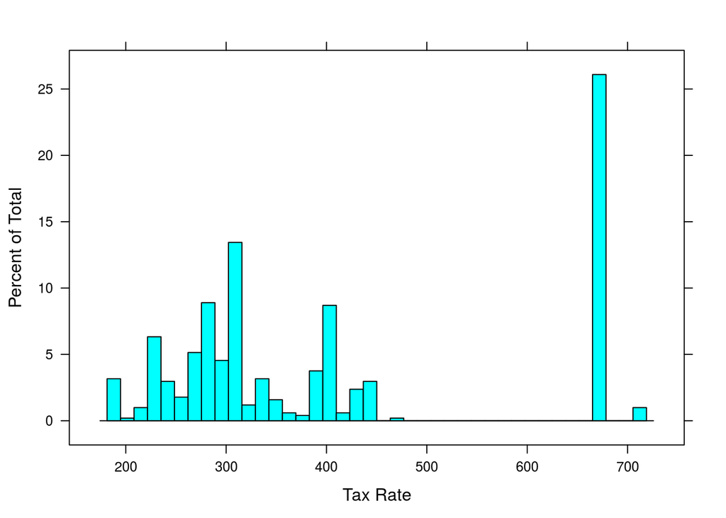

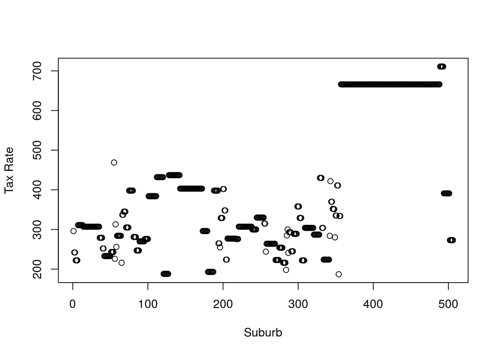

#### Pupil-Teacher Ratio

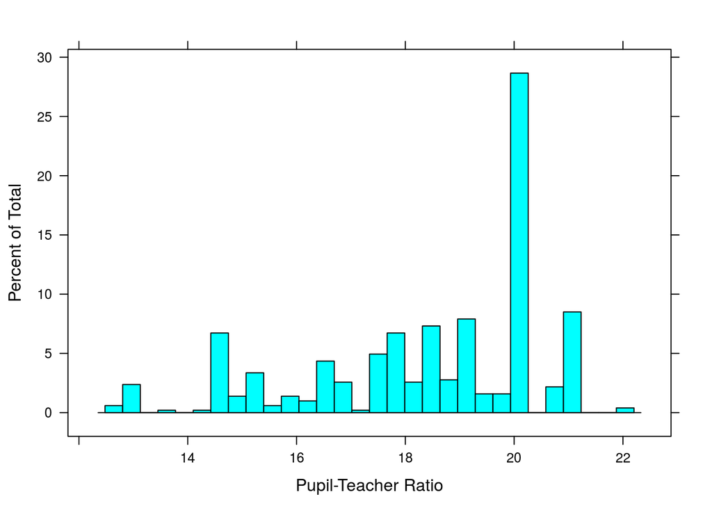

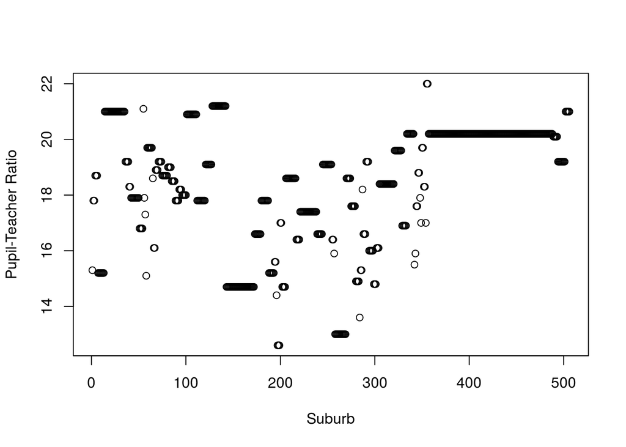

5. 35 suburbs in this data set bound the Charles river.
6. the median pupil-teacher ratio among the towns is **19.05**.

| Suburb(Index) | crim | zn | indus | chas | nox | rm | age | dis | rad | tax | ptratio | black | lstat | medv |
| --- | --- | --- | --- | --- | --- | --- | --- | --- | --- | --- | --- | --- | --- | --- |
| range | 0.01, 88.98 | 0, 100 | 0.46, 27.74 | 0, 1 | 0.38, 0.87 | 3.56, 8.78 | 2.9, 100 | 1.13, 12.13 | 1, 24 | 187, 711 | 12.6, 22 | 0.32, 396.9 | 1.73, 37.97 | 5, 50 |
| mean | 3.61 | 11.36 | 11.14 | 0.07 | 0.55 | 6.28 | 68.57 | 3.8 | 9.55 | 408.24 | 18.46 | 356.67 | 12.65 | 22.53 |
| 399 | 38.3518 | 0 | 18.1 | 0 | 0.693 | 5.453 | 100 | 1.4896 | 24 | 666 | 20.2 | 396.9 | 30.59 | 5 |
| 406 | 67.9208 | 0 | 18.1 | 0 | 0.693 | 5.683 | 100 | 1.4254 | 24 | 666 | 20.2 | 384.97 | 22.98 | 5 |

- 64 suburbs average more than 7 rooms per dwelling.
- 13 suburbs average more than 8 rooms per dwelling.

The majority of the suburbs averaging more than 8 rooms per dwelling appear to be older suburbs that have a high proportion of buildings built prior to 1940. They also have low per capita crim rates. A third observation is they all have high black proportions.